# The beta-binomial model

2025-02-18

## 0. Introduction

Este texto aborda as distribuições de Bernoulli e Binomial, utilizadas para modelar resultados binários. Primeiro, definimos o modelo e a sua visualização. Em seguida, focamo-nos na estimação do parâmetro **p** usando estatística de Máxima Verosimilhança (ML) e Bayesiana.

# 1. A Distribuição de Bernoulli

A **distribuição de Bernoulli** é uma distribuição de probabilidade discreta que descreve um experimento com **apenas dois possíveis resultados**: **sucesso** (codificado como 1) e **falha** (codificado como 0).

## 1.1. Função de Massa de Probabilidade (PMF)

A função de massa de probabilidade (pmf) da distribuição de Bernoulli é dada por:

$$P(X = x) =
\begin{cases}
p, & \text{se } x = 1 \\
1 - p, & \text{se } x = 0
\end{cases}$$

onde:

- **p** é a **probabilidade de sucesso** (a probabilidade de obter $x = 1$).
- **( 1 - p )** é a **probabilidade de falha** (a probabilidade de obter $x = 0$).

## 1.2. Propriedades Importantes

A distribuição de Bernoulli tem as seguintes propriedades:

### 1.2.1 **Probabilidade de Sucesso**

A probabilidade de sucesso é representada por $p$, que é:

$$p = P(X = 1)$$

Isso significa que, em um único ensaio de Bernoulli, a probabilidade de obter um sucesso (ou seja, $X = 1$) é $p$.

### 1.2.2. **Valor Esperado**

O **valor esperado** ou **média** de uma variável aleatória $X$ de uma distribuição de Bernoulli é dado por:

$$E[X] = p$$

Ou seja, o valor médio ou esperado de $X$ ao longo de muitos ensaios independentes será igual à probabilidade de sucesso $p$.

### 1.2.3 **Variância**

A **variância** de uma variável aleatória $X$ de uma distribuição de Bernoulli mede o quanto os resultados podem variar em torno do valor esperado. Ela é dada por:

$$\text{Var}[X] = p(1 - p)$$

Essa fórmula indica que a variância depende da probabilidade de sucesso $p$ e da probabilidade de falha $1 - p$. Quanto mais próximo $p$ estiver de 0 ou 1, menor será a variância, e quanto mais $p$ for próximo de 0.5, maior será a variância.

## 1.3. Exemplos de Aplicação

A distribuição de Bernoulli é útil em vários contextos, especialmente quando temos eventos com dois resultados possíveis, como: - Lançamento de uma moeda (cara ou coroa). - Teste de um medicamento (funciona ou não funciona). - Aceitação ou rejeição de uma proposta (aceite ou rejeitada).

## 1.4. Exemplo de uma Distribuição Bernoulli

O próximo exemplo simula uma amostra de tamanho 1000 a partir de uma população de Bernoulli com $p = 0.3$.

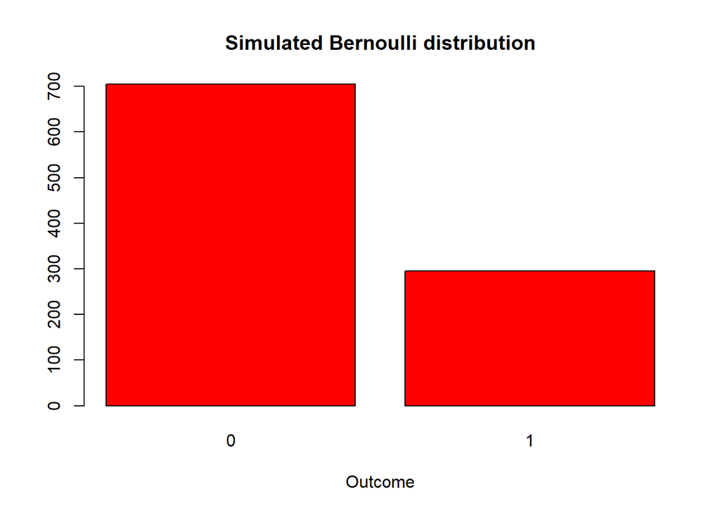

```r
# Simulate Bernoulli distribution

set.seed(123)
p_success <- 0.3
bernoulli_data <- rbinom(1000, size = 1, prob = p_success)

# Plot simulated data

barplot(table(bernoulli_data), main = "Simulated Bernoulli distribution", xlab = "Outcome", col = "red", border = "black")
```

### Resumo:

- **$p$**: Probabilidade de sucesso (1).
- **$E[X] = p$**: O valor esperado é igual à probabilidade de sucesso.
- **$\text{Var}[X] = p(1 - p)$**: A variância depende da probabilidade de sucesso e falha.

# 2 The binomial distribution

A distribuição binomial modela o número de sucessos em um número fixo de ensaios de Bernoulli independentes.

A função de massa de probabilidade (pmf) da distribuição binomial é dada por:

$$P(X = x) = \binom{m}{x} p^x (1 - p)^{m - x}$$

onde  
- $m$ é o número de ensaios independentes,  
- $x$ é o número de sucessos, e  
- $p$ é a probabilidade de sucesso em um único ensaio.

No caso da distribuição binomial, temos:

$$E[X] = mp$$

e

$$\text{Var}[X] = mp(1 - p).$$

Para $m = 1$, a distribuição binomial reduz-se à distribuição de Bernoulli.

O próximo exemplo simula uma amostra de 2000 observações de uma população binomial com $p = 0.4$ e $m = 10$.

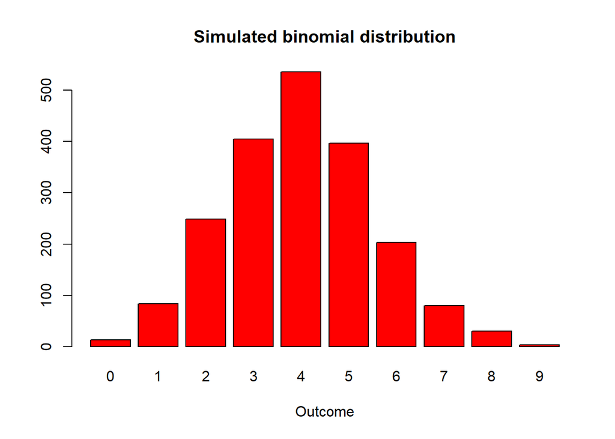

```r
# Simulate binomial distribution

set.seed(123)
p_success <- 0.4
n_trials <- 10
binomial_data <- rbinom(2000, size = n_trials, prob = p_success)

# Plot simulated data

barplot(table(binomial_data), main = "Simulated binomial distribution", xlab = "Outcome", col = "red", border = "black")
```